# Numerical Methods of Accelerator Physics

## Lecture by Dr. Adrian Oeftiger

[figure not shown]

### Part 2: 28.10.2022

## Run this notebook online!

Interact and run this jupyter notebook online:

1. via the public mybinder.org service:

2. on the [local TU Darmstadt jupyterhub $\nearrow$](https://tu-jupyter-i.ca.hrz.tu-darmstadt.de/) (using your TU ID)

$\implies$ make sure you installed all the required python packages (see the README)!

Finally, also find this lecture rendered [as HTML slides on github $\nearrow$](https://aoeftiger.github.io/TUDa-NMAP-02/) along with the [source repository $\nearrow$](https://github.com/aoeftiger/TUDa-NMAP-02).

## Since last week

- jupyter notebooks on your devices?
- experience with running them online in mybinder?
- local TU Darmstadt resources: jupyter hub (require TU IDs!)

### Announcements

- starting flipped classroom after next week
- first video material: lecture part 4, available Monday 7.11.2022

## Refresher!

- accelerators $=$ $1 + \epsilon$ $=$ single-particle dynamics + perturbative multi-particle dynamics
- bending and focusing concept
- linacs vs. cyclotrons vs. synchrotrons
- synchrotron time scales: transverse oscillations vs. longitudinal oscillations vs. storage time
- phase space
- equations of motion and the Hamiltonian
- discrete integration
- Liouville theorem, symplecticity

## Today!

1. RMS Emittance and Preservation
2. Discrete Frequency Analysis

## Maxwell Equations

Beam $=$ ensemble of particles

$\leadsto$ particles subject to electromagnetic fields $\implies$ 3D Maxwell equations

in Cartesian coordinates:

$$\begin{align}\, &(1) & \nabla \cdot \mathbf{E} &= \frac{\rho}{\epsilon_0} \\ &(2) & \nabla \times \mathbf{E} + \frac{\partial\mathbf{B}}{\partial t} &= \mathbf{0} \\ &(3) & \nabla \cdot \mathbf{B} &= 0 \\ &(4) & \nabla \times \mathbf{B} - \frac{1}{c^2} \frac{\partial\mathbf{E}}{\partial t} &= \mu_0 \mathbf{j} \end{align}$$

## Coordinate System in Accelerators

[figure not shown]

**Reference orbit**: ideal trajectory through magnets in accelerator

**Path length** $s$: independent time-like parameter following reference particle with momentum $p_0=\beta\gamma m_0 c$ in longitudinal direction

Particle 3D position in accelerator is measured as **3D offset** from the reference orbit position at path length $s$:

$$(x,y,z)$$$$\begin{align} x& \text{: horizontal offset [m]} \\ y& \text{: vertical offset [m]} \\ z& \text{: longitudinal offset [m]} \end{align}$$

## Conjugate Momenta

Longitudinal momentum in the direction of motion $p_z$.

Transverse momenta $P_x, P_y$ are typically expressed as trajectory slopes: $$\begin{align}\, x' &\doteq \frac{dx}{ds} = \frac{P_x}{p_z} \\ y' &\doteq \frac{dy}{ds} = \frac{P_y}{p_z} \end{align}$$

$\leadsto$ **Paraxial approximation**: $x'\ll 1,~ y'\ll 1,~ p_z\approx p_0$

$\implies$ measure $p_z$ as momentum offset from $p_0$: $\delta = \frac{p_z - p_0}{p_0}$

## 6D Phase Space

A point particle $\implies$ occupies a point in 6D phase space:

$$\zeta = \begin{pmatrix} x \\ x' \\ y \\ y' \\ z \\ \delta \end{pmatrix}$$

In typical synchrotron situations: horizontal $(x,x')$ and vertical $(y,y')$ phase space are **decoupled**!

$\implies$ will study when this approximation applies during derivation of reduced transverse and longitudinal models!

[figure not shown]

## Analogy of Pendulum with Accelerator

Longitudinal phase focusing with rf cavities:

- particles drift over most of the circular accelerator
- particles get kicked only in rf cavities  
  (energy change through standing electromagnetic wave)

$\implies$ closely corresponds to discrete pendulum situation!

rf focused beam of particles $\leftrightarrow$ **collection** of pendulums

[image: LEIR layout, CERN](https://be-dep-op-leir.web.cern.ch/content/leir-machine)

## Let's simulate collection of pendulums

```python
from config import (np, plt, hamiltonian,
                    plot_hamiltonian, solve_leapfrog,
                    get_boundary_ids, set_axes,
                    plot_macro_evolution, dt)
%matplotlib inline
```

Create distribution of initial conditions $(\theta_i, p_i)$ for the pendulum (like a beam of $N$ particles):

```python
theta_grid = np.linspace(-0.5 * np.pi, 0.5 * np.pi, 21)
p_grid = np.linspace(-0.3, 0.3, 5)

thetas, ps = np.meshgrid(theta_grid, p_grid)
```

```python
N = len(theta_grid) * len(p_grid)
N
```

```
105
```

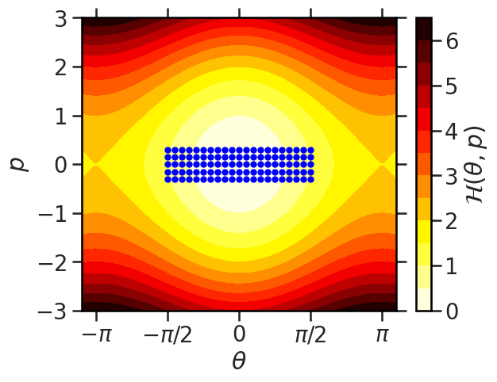

```python
plt.scatter(thetas, ps, c='b', marker='.')

plot_hamiltonian()
```

$\implies$ rectangular distribution (reminds of a beam pulse injected from a linac)

## Beam Emittance

[figure not shown]

Beam distribution: $10^{11}...10^{13}$ particles

$\leadsto$ refer to extent of distribution in phase space as **emittance**  
$\epsilon=$ rms of all particle amplitudes!

## Moment of a distribution

Measure statistical moments of a distribution of $N$ particles/states in phase space:

$$\langle f(\zeta) \rangle \doteq \frac{1}{N}\sum\limits_i^N f(\zeta_i)$$

where $f$ is a monomial of the phase-space coordinates, e.g.

$$\begin{cases} \langle x \rangle: & \text{horizontal centroid (centre-of-mass)} \\ \sigma_y = \sqrt{\left\langle \bigl(y - \langle y \rangle \bigr)^2\right\rangle} = \sqrt{\langle y^2 \rangle - \langle y\rangle^2}: & \text{vertical rms beam size} \end{cases}$$

$\implies$ what is the moment order of $\langle x\rangle$ or $\sigma_y$?

## Statistical RMS Emittance

Measure **extent** of distribution in phase space via $\Sigma$-matrix, the covariance matrix of second-order moments, e.g. for horizontal phase space (assume for simplicity $\langle x\rangle=\langle x'\rangle=0$):

$$\Sigma_x = \begin{pmatrix} \langle x^2\rangle & \langle x\,x'\rangle \\ \langle x\,x'\rangle & \langle x'{}^2\rangle \\ \end{pmatrix}$$

$\implies$ the **rms emittance** is given by:

$$\epsilon_x = \sqrt{\det \Sigma_x} = \sqrt{\langle x^2\rangle \langle x'{}^2\rangle - \langle x\,x'\rangle^2}$$

$\leadsto$ a value for the "thermal energy" of the distribution

(for $\langle x\rangle,\langle x'\rangle\neq 0$ need to subtract them: $x\mapsto x-\langle x\rangle$ and $x'\mapsto x'-\langle x'\rangle$)

## Time evolution

Numerical integration of equations of motion for distribution of pendulums, using leapfrog (drift+kick+drift):

```python
n_steps = 100
```

```python
results_thetas = np.zeros((n_steps, N), dtype=np.float32)
results_thetas[0] = thetas.flatten()

results_ps = np.zeros((n_steps, N), dtype=np.float32)
results_ps[0] = ps.flatten()

for k in range(1, n_steps):
    results_thetas[k], results_ps[k] = solve_leapfrog(results_thetas[k - 1], results_ps[k - 1])
```

## Observations of Centroids

Before we look at all "particles" (pendulums), check evolution of some distribution moments:

```python
centroids_theta = 1/N * np.sum(results_thetas, axis=1)
centroids_p = 1/N * np.sum(results_ps, axis=1)
```

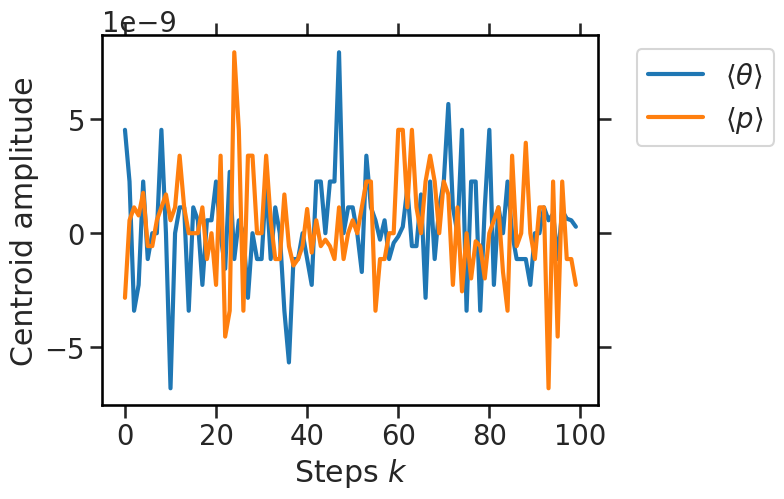

```python
plt.plot(centroids_theta, label=r'$\langle\theta\rangle$')
plt.plot(centroids_p, label=r'$\langle p\rangle$')

plt.xlabel('Steps $k$')
plt.ylabel('Centroid amplitude')
plt.legend(bbox_to_anchor=(1.05, 1));
```

$\implies$ can you explain this?

## Observations of RMS Sizes

Before we look at all "particles" (pendulums), check evolution of some distribution moments:

```python
var_theta = 1/N * np.sum(results_thetas * results_thetas, axis=1)
var_p = 1/N * np.sum(results_ps * results_ps, axis=1)
```

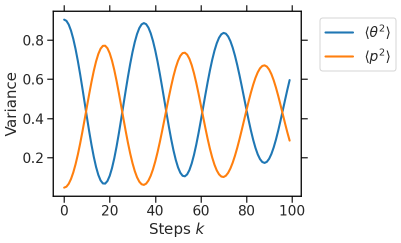

```python
plt.plot(var_theta, label=r'$\langle\theta^2\rangle$')
plt.plot(var_p, label=r'$\langle p^2\rangle$')

plt.xlabel('Steps $k$')
plt.ylabel('Variance')
plt.legend(bbox_to_anchor=(1.05, 1));
```

$\implies$ can you explain this?

## Mismatch of Distributions

Non-linearity of the pendulum equation: decreased oscillation frequency at larger amplitudes!

A) matched distribution:

[figure not shown]

B) mismatched distribution:

[figure not shown]

$\implies$

[figure not shown]

## Filamentation

- Liouville theorem (incompressible phase-space fluid) still valid, local density conserved
- occupied global phase-space area by beam seemingly enlarged
- reason: **filamentation** due to non-linearity:  
  $\implies$ non-linear potential $\longrightarrow$ oscillation frequency depends on amplitude $\implies$ anharmonicity
- consequence: rms emittance increases (in previous example: $\Delta\epsilon/\epsilon=30\%$)

## Back to our pendulum simulation:

Observe distribution evolution over the $k$ steps:

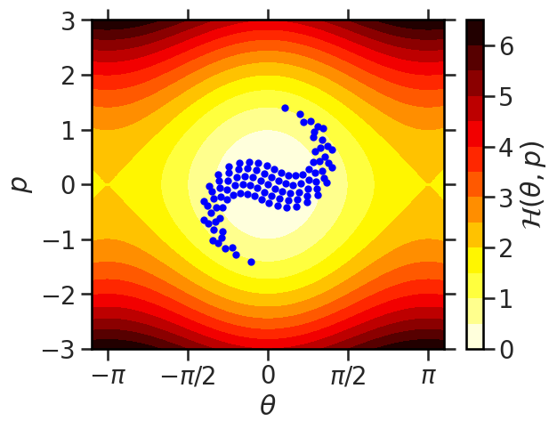

```python
k = 99

plt.scatter(results_thetas[k], results_ps[k], c='b', marker='.')

plot_hamiltonian()
```

## RMS Emittance Evolution

Let us compute the rms emittance for the pendulums (having subtracted the centroids),

$$\epsilon = \sqrt{\langle \theta^2\rangle \langle p^2\rangle - \langle \theta\,p\rangle^2}$$

```python
def emittance(theta, p):
    N = len(theta)

    # subtract centroids
    theta = theta - 1/N * np.sum(theta)
    p = p - 1/N * np.sum(p)

    # compute Σ matrix entries
    theta_sq = 1/N * np.sum(theta * theta)
    p_sq = 1/N * np.sum(p * p)
    crossterm = 1/N * np.sum(theta * p)

    # determinant of Σ matrix
    epsilon = np.sqrt(theta_sq * p_sq - crossterm * crossterm)
    return epsilon
```

```python
results_emit = np.zeros(n_steps, dtype=np.float32)

for k in range(n_steps):
    results_emit[k] = emittance(results_thetas[k], results_ps[k])
```

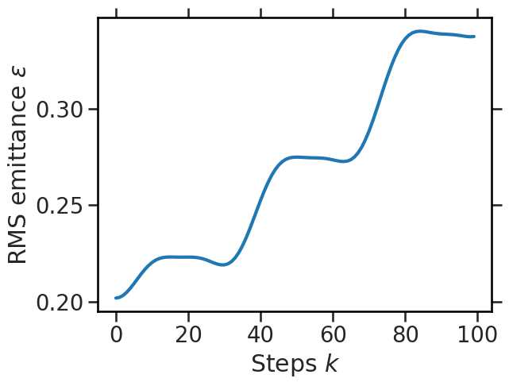

```python
plt.plot(results_emit)

plt.xlabel('Steps $k$')
plt.ylabel('RMS emittance $\epsilon$');
```

$\implies$ rms emittance grows, macroscopic increase of "thermal energy"!

## Microscopic Level?

What about Liouville theorem?

$\implies$ For the symplectic integrator, still expect (and have) constant phase-space trajectory density!

**Exercise**: integrate around a small area and follow it during the simulation.

## Emittance vs. Linear Dynamics

$\implies$ What happens with the rms emittance in case of linear dynamics (absence of non-linearities)?

**Exercise**:

- Taylor-expand the sine function in the pendulum equations of motion
- cut after first order: $\sin\theta \approx \theta + \mathcal{O}(\theta^3)$
- re-run the simulation for this linear system (why is this system linear now?)
- observe the variances as well as emittance evolution!
- can you explain why the emittance behaves this way (in contrast to non-linear model?)

## Note: Modelling error

Typical example:

$\implies$ Taylor-expand potential $U\propto \sin\theta$ to a certain finite order

$\implies$ large amplitudes are behaved differently from original pendulum!

$\implies$ error in approximation $=$ **modelling error**

(in contrast to **discretisation error**, see last lecture)

## Centroid offset in (Original) Pendulum

Consider again the non-linear pendulum: let us offset the initial centroid $\langle \theta\rangle$!

```python
results_thetas2 = np.zeros((n_steps, N), dtype=np.float32)
results_thetas2[0] = thetas.flatten() + 0.1 * np.pi

results_ps2 = np.zeros((n_steps, N), dtype=np.float32)
results_ps2[0] = ps.flatten()

for k in range(1, n_steps):
    results_thetas2[k], results_ps2[k] = solve_leapfrog(results_thetas2[k - 1], results_ps2[k - 1])
```

$\implies$ will the rms emittance growth be smaller / equal / larger?

## Observation of Centroids II

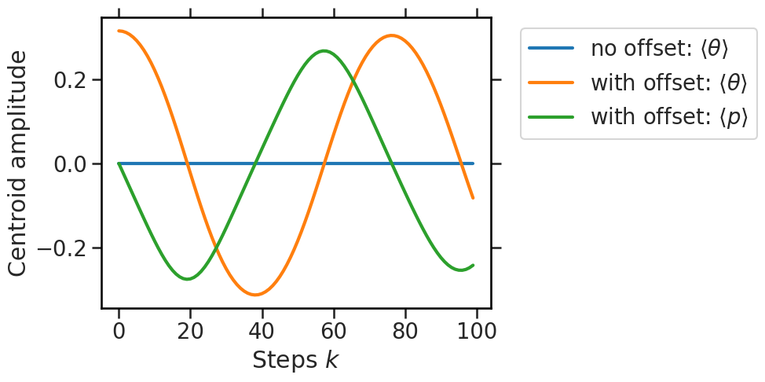

```python
centroids_theta2 = 1/N * np.sum(results_thetas2, axis=1)
centroids_p2 = 1/N * np.sum(results_ps2, axis=1)

plt.plot(centroids_theta, label=r'no offset: $\langle\theta\rangle$')
plt.plot(centroids_theta2, label=r'with offset: $\langle\theta\rangle$')
plt.plot(centroids_p2, label=r'with offset: $\langle p\rangle$')

plt.xlabel('Steps $k$')
plt.ylabel('Centroid amplitude')
plt.legend(bbox_to_anchor=(1.05, 1));
```

## RMS Emittance Evolution II

```python
results_emit2 = np.zeros(n_steps, dtype=np.float32)

for k in range(n_steps):
    results_emit2[k] = emittance(results_thetas2[k], results_ps2[k])
```

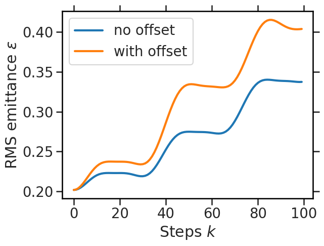

```python
plt.plot(results_emit, label='no offset')
plt.plot(results_emit2, label='with offset')

plt.xlabel('Steps $k$')
plt.ylabel('RMS emittance $\epsilon$')
plt.legend();
```

## Long-term Behaviour

```python
n_steps = 3000
```

```python
results_thetas3 = np.zeros((n_steps, N), dtype=np.float32)
results_thetas3[0] = thetas.flatten() + 0.1 * np.pi

results_ps3 = np.zeros((n_steps, N), dtype=np.float32)
results_ps3[0] = ps.flatten()

for k in range(1, n_steps):
    results_thetas3[k], results_ps3[k] = solve_leapfrog(results_thetas3[k - 1], results_ps3[k - 1])
```

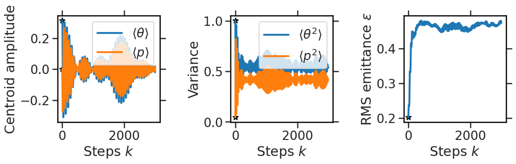

```python
plot_macro_evolution(results_thetas3, results_ps3);
```

$\implies$ observations:

- oscillations of all moments dampen out until residual noise level
- emittance growth saturates rather quickly

## Important Notes on RMS Emittance Evolution

Reminder of Basic Thermodynamic Principle: $\delta S \geq 0$

RMS emittance:

- constant or grows for conservative forces (closed systems)
- in accelerator systems, only ways to reduce / dampen emittance:
  - synchrotron radiation
  - electron cooling
  - stochastic cooling (Nobel prize: van de Meer)

## Emittance Preservation

[figure not shown]

$\implies$ avoid **injection mismatch** when transferring  
beam between accelerators:

- centroid mismatch
- rms beam size mismatch

$\implies$ avoid resonances / instabilities

$\implies$ preserve (energy-normalised) emittance to obtain small beams for experiments and accelerator aperture constraints!

$\implies$ require **accurate numerical simulation models** for predictions!

[image: CERN 2022](http://cds.cern.ch/images/CERN-GRAPHICS-2022-001-1)

## Representation of Particle Beam

[figure not shown]

[image: Alex Chao 2018 at the CAS](https://cas.web.cern.ch/sites/default/files/lectures/thessaloniki-2018/cas2018chao.pdf)

## Summing Up Concepts

- **non-linearities** in dynamical system $\implies$ oscillation frequency depends on amplitude $\implies$ **anharmonicity**
- microscopic: **Liouville** (density of phase-space trajectories conserved)
- macroscopic: **filamentation**
- **rms emittance**: macroscopic extent of distribution in phase space
- control of simulation errors: discretisation errors, modelling errors, numerical artefacts (see later!)

$\implies$ rms emittance preservation in accelerators $\longleftrightarrow$ accurate modelling of non-linear accelerator system

## Continuous Pendulum: Linear Oscillation Frequency

Reminder:

Equation of motion: $$\frac{d^2\theta}{dt^2} + \frac{g}{L}\sin\theta = 0$$

for $\sin\theta\approx \theta$: $$\implies \frac{d^2\theta}{dt^2} + \underbrace{\frac{g}{L}}\limits_{\mathop{=}\omega^2}\theta = 0$$

During a time step $\Delta t=0.1$, the phase advance (in units of 2π) gives:

```python
freq_theory = np.sqrt(1 / 1) * 0.1 / (2 * np.pi)
freq_theory
```

```
0.015915494309189534
```

## Determining Oscillation Frequencies

Can we quantify the change of oscillation frequency towards larger amplitudes?

$\implies$ DFT: Discrete Fourier Transform technique

$$f_n = \sum\limits_{k=0}^{N_\mathrm{step}-1} \theta_{k}\,e^{-i2\pi\frac{n}{N_\mathrm{step}} k}$$

Obtain frequency components $f_n$ from signal $\theta_k$ recorded over $N_\mathrm{step}$ steps.

## FFT: Efficient Algorithm for $N_{step}=2^\ell$

Fast Fourier Transform (FFT): among 10 most influential algorithms in 20th century!

- continuous splitting of DFT summation:

$$ f_n = \sum\limits_{p=0}^{\frac{N_\mathrm{step}}{2}-1} \theta_{2p}\,e^{-i2\pi\frac{n}{N_\mathrm{step}}2p} + e^{-i2\pi\frac{n}{N_\mathrm{step}}} \sum\limits_{p=0}^{\frac{N_\mathrm{step}}{2}-1} \theta_{2p+1}\,e^{-i2\pi\frac{n}{N_\mathrm{step}}2p}$$

- exploiting symmetry identify of DFT: $f_{n+jN_mathrm{step}} = f_{n}$ for $j=0,1,2...$
- basic DFT: complexity $\mathcal{O}(N_\mathrm{step}^2)$
- vs. FFT: complexity $\mathcal{O}(N_\mathrm{step}\,\log_2 N_\mathrm{step})$

$\implies$ timing comparison DFT vs. FFT for $N_\mathrm{step}=10^9$ and 1 ns time per compute operation?

## Employ FFT on Pendulum Motion

Observe two particles:

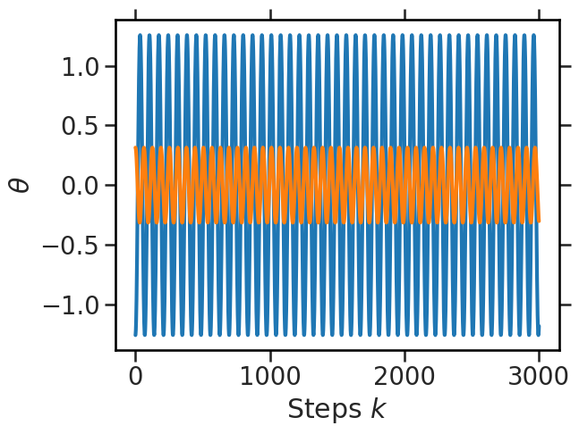

```python
i1 = N // 2 - 10
i2 = N // 2

plt.plot(results_thetas3[:, i1])
plt.plot(results_thetas3[:, i2])
plt.xlabel('Steps $k$')
plt.ylabel(r'$\theta$');
```

Obtain the FFT spectra for both:

```python
spec1 = np.fft.rfft(results_thetas3[:, i1])
spec2 = np.fft.rfft(results_thetas3[:, i2])

freq = np.fft.rfftfreq(n_steps)
```

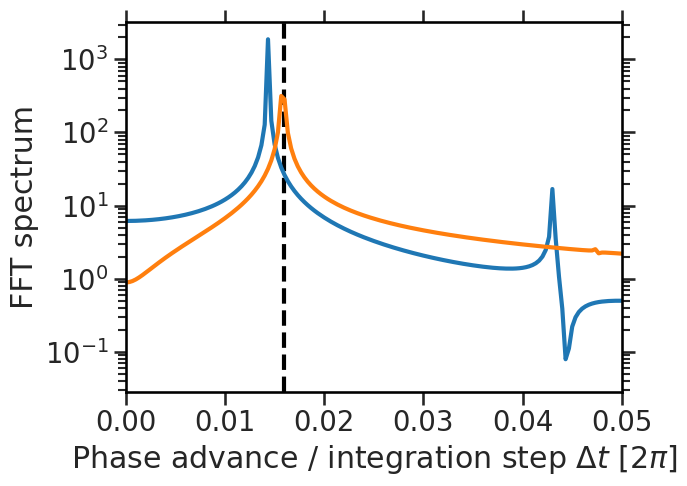

```python
plt.plot(freq, np.abs(spec1))
plt.plot(freq, np.abs(spec2))
plt.axvline(freq_theory, c='k', zorder=0, ls='--')
plt.xlim(0, 0.05)
plt.xlabel('Phase advance / integration step $\Delta t$ [$2\pi$]')
plt.ylabel('FFT spectrum')
plt.yscale('log');
```

## Frequency vs. Amplitude

Let us plot the maximum frequency vs. initial $\theta$ (where $p=0$):

```python
specs = np.abs(np.fft.rfft(results_thetas3.T))
```

```python
max_ids = np.argmax(specs, axis=1)
amplitudes = np.max(specs, axis=1)
```

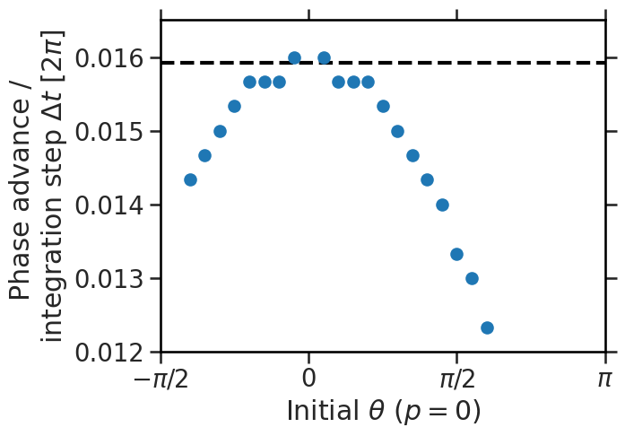

```python
i_range = np.where(ps.flatten() == 0)[0]

plt.scatter(results_thetas3[0][i_range], freq[max_ids][i_range])

plt.axhline(freq_theory, c='k', ls='--', zorder=0)
plt.xticks([-np.pi/2, 0, np.pi/2, np.pi], [r"$-\pi/2$", "0", r"$\pi/2$", r"$\pi$"])
plt.xlabel(r'Initial $\theta$ ($p=0$)')
plt.ylabel('Phase advance / \n' + r'integration step $\Delta t$ [$2\pi$]');
plt.ylim(0.012, 0.0165);
```

$\implies$ what is responsible for the step behaviour / finite resolution of the vertical values? How would you further increase the resolution in this plot?

## The NAFF Algorithm

J. Laskar describes in 1989: "The Chaotic Motion of the Solar System: A Numerical Estimate of the Size of Chaotic Zones"

NAFF $=$ **N**umerical **A**nalysis of **F**undamental **F**requencies

$\implies$ [quasi-periodic decomposition](https://arxiv.org/pdf/math/0305364.pdf): **iterative** fitting of (not necessarily orthogonal) fundamental frequencies for numerical signal over finite time span.

In accelerator physics, sometimes find equivalent formulation as [SUSSIX algorithm](http://frs.home.cern.ch/frs/Source/other_tools/sussix/documentation/sussix_manual.pdf).

Usage:

- celestial mechanics
- particle accelerators
- atomic physics
- general dynamical system issues (Hamiltonian dynamics, chaos)

## Frequency Accuracy for Periodic Motion

```python
import PyNAFF
```

```python
freqs_naff = []

for signal in results_thetas3.T[i_range]:
    freq_naff = PyNAFF.naff(signal, turns=n_steps - 1, nterms=1)
    try:
        freq_naff = freq_naff[0, 1]
    except IndexError:
        freq_naff = 0
    freqs_naff += [freq_naff]

freqs_naff = np.array(freqs_naff)
```

```
## PyNAFF::naff: Remove the DC component from the data (i.e. the mean).
```

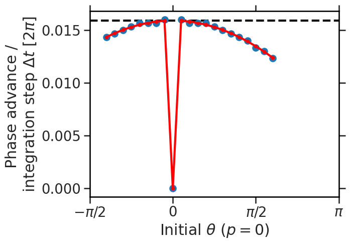

```python
plt.scatter(results_thetas3[0][i_range], freq[max_ids][i_range])
plt.plot(results_thetas3[0][i_range], freqs_naff, c='r', marker='.')

plt.axhline(freq_theory, c='k', ls='--', zorder=0)
plt.xticks([-np.pi/2, 0, np.pi/2, np.pi], [r"$-\pi/2$", "0", r"$\pi/2$", r"$\pi$"])
plt.xlabel(r'Initial $\theta$ ($p=0$)')
plt.ylabel('Phase advance / \n' + r'integration step $\Delta t$ [$2\pi$]');
```

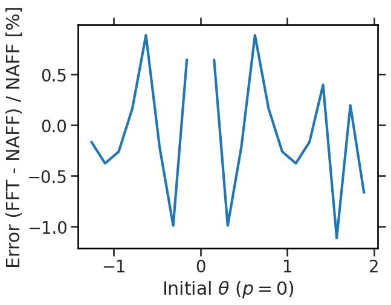

```python
plt.plot(results_thetas3[0][i_range], 100 * (freq[max_ids][i_range] - freqs_naff) / freqs_naff)
plt.xlabel(r'Initial $\theta$ ($p=0$)')
plt.ylabel('Error (FFT - NAFF) / NAFF ' + r'[%]');
```

## Summary

- statistical moments
- rms emittance
- filamentation: microscopic level Liouville vs. macroscopic emittance growth
- emittance preservation and injection mismatch
- modelling error (in addition to discretisation error last lecture)
- discrete frequency analysis: FFT and NAFF

## Literature

- NAFF and precision:

[J. Laskar, Introduction to Frequency Map Analysis](https://link.springer.com/chapter/10.1007/978-94-011-4673-9_13)